# lab3_hiv_env_pol_comparison_solutions

## Mutations in the HIV Env and Pol genes

```python
from datascience import *
%matplotlib inline
import matplotlib.pyplot as plots
import numpy as np
plots.style.use('fivethirtyeight')
```

## Import the data

Again, our data will come from [LANL HIV database](http://www.hiv.lanl.gov).

```python
# the tables object is actually a bit clunky for us,
# so we will just import the sequences directly into a list
env_seqs=Table.read_table(
    'https://raw.githubusercontent.com/shishiluo/Genomics-DataScience/master/data/hiv-1_env_north_america_aligned.csv')\
.column('Sequence')
```

```python
len(env_seqs)
```

```
456
```

```python
env_seqs[0].upper()
```

```
'ATGAAAGCGAAGGGGACCAGGAGGA------------ATTA---T---CAGCACTT---G---T-------GGAGAGG------------------------------GGGCATGATG---------CTCCTTGG---GATG---TTA-------ATGAT------------CTGT-AGTGCTGC---------------AGC---AAAT---TTG------------------TGGGTCACAGTCTATTATGGAGTACCAGTGTGGAGAGAGGCAA-ACACCACTCTATTTTGTGCAT…
```

All these sequences are **aligned**, which means that they are the same length. The '-' in the sequences have been placed in the most appropriate locations so that sequences line up. These dashes represent base pairs that were potentially inserted or deleted, 'indels'.

The procedure of putting in these dashes in an automated and rigorous manner is called **alignment**. Although there are standard algorithms for alignment, there is no guarantee that the alignment produced represents the true mutational events that occurred.

However, because HIV-1 is so well characterized, we can more or less trust these alignments.

In addition to the env gene, we will also look at the pol gene. We can obtain the data the same way.

```python
pol_seqs=Table.read_table(
    'https://raw.githubusercontent.com/shishiluo/Genomics-DataScience/master/data/hiv-1_pol_north_america_aligned.csv')\
.column('Sequence')
```

## 2. Quantifying variation I

There is no set way to quantify how much variation we see in a sample. One way is to look at each position and see how many variants (i.e. different symbols) are found in that position.

Let's do this for the first four positions.

```python
for pos in range(4):
    print(pos, set([l[pos].upper() for l in env_seqs]))
```

```
0 {'A', 'T', 'C'}
1 {'T', 'C'}
2 {'A', 'G'}
3 {'A', 'G'}
```

Let's break this down  
`l[pos].upper()`

`[l[pos].upper() for l in env_seqs]`

`set([l[pos].upper() for l in env_seqs])`

**Q1**: Modify the above script so that the output is the number of unique characters.

```python
len(set(['a', 'a', 'G']))
```

**Q2**: Use the code you have so far to count the number of variants for each position in the gene and store it in a numpy array called `env_num_variants`

```python
env_len=3576
env_num_variants=np.zeros((env_len,))
for pos in range(env_len):
    env_num_variants[pos]=len(set([l[pos].upper() for l in env_seqs]))
```

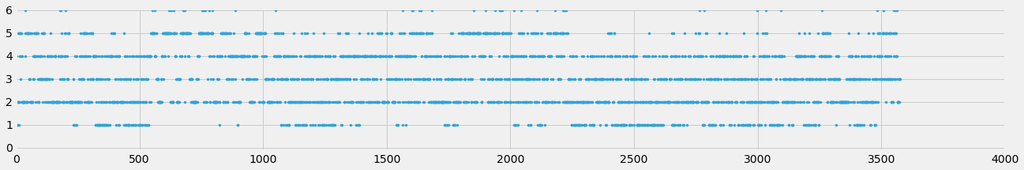

```python
# let's plot our counts
plots.figure(figsize=(20,3))
plots.plot(env_num_variants, '.')
plots.ylim([-.1,6.1])
plots.show()
```

**Q3**: Why is this figure so difficult to parse?

Maybe `env_num_variants` can be plotted differently to be more meaningful. Let's try putting a vertical bar at each position with height equal to the number of variants:

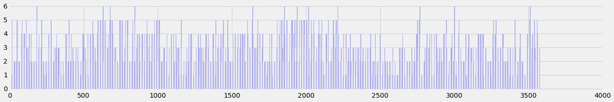

```python
plots.figure(figsize=(20,3))
plots.bar(np.arange(env_len),env_num_variants, width=.5)
plots.ylim([-.1,6.1])
plots.show()
```

This is looking better, but nothing's jumping out at us.

What if we only plot the positions that have a single variant represented in the sample?

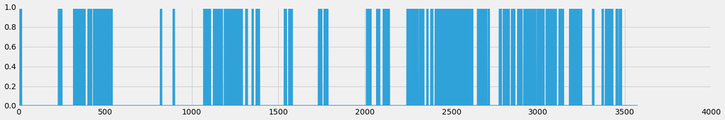

```python
plots.figure(figsize=(20,3))
plots.plot(env_num_variants==1)
```

But this is also problematic because this makes some regions that have variation (like the region around 500bp) look like they're conserved across sequences.

Sometimes, the easiest thing for our brains to understand is a single number.  
**Q4**: Calculate the fraction of positions in env that have a single variant.

```python
np.sum(env_num_variants==1)/env_len
```

```
0.098713646532438484
```

**Q5**: Quantify variation using similar methods for the pol gene sequences in `pol_seqs`.

```python
len(pol_seqs[0])
```

```
3238
```

```python
pol_len=3238
pol_num_variants=np.zeros((pol_len,))
for pos in range(pol_len):
    pol_num_variants[pos]=len(set([l[pos].upper() for l in pol_seqs]))
```

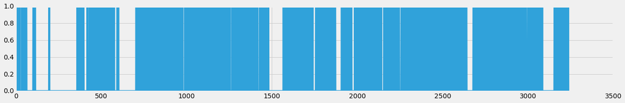

```python
plots.figure(figsize=(20,3))
plots.plot(pol_num_variants==1)
```

```python
np.sum(pol_num_variants==1)/pol_len
```

```
0.27949351451513282
```

**Q6**: In a few sentences, state whether env or pol has more variation, and support your claim with quantitative evidence.

## Quantifying variation II

One of the problems of only counting the number of variants is that rare mutants get as much weight as common ones. We can try to get around this by looking at the relative frequencies of each variant and reporting the frequency of the most common variant for each position.

Let's practice this on the first position of the env gene.

```python
first_pos=np.array([l[0].upper() for l in env_seqs])
```

**Q7**: Write code that returns the frequency of the most common variant in `first_pos`.

One way to do this is to first make a list of the unique variants. Then, for each unique variant, count the number of times it appears in `first_pos`. Finally, divide the count by the length `first_pos` to get a fraction.

**Q8**: Now put this code in a loop that scans the full env gene and stores the max frequencies for each position in the array `env_max_freq`.

```python
env_max_freq=np.zeros((env_len,))
for pos in range(env_len):
    bases=np.array([l[pos].upper() for l in env_seqs])
    variants=set(bases)
    if len(variants)==1:
        env_max_freq[pos]=1 # all are the same type
    else:
        freqs=[]
        for v in variants:
            freqs.append(np.sum((bases==v))/len(bases))
        env_max_freq[pos]=max(freqs)
```

Let's visualize what we just calculated:

```
(0, 1)
```

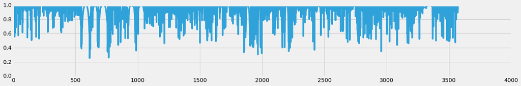

```python
plots.figure(figsize=(20,3))
plots.plot(env_max_freq)
plots.ylim([0,1])
```

There seems to be some interesting behavior, especially in positions around 600-700 and 1800-2000. It's a little difficult to know what's going on in the dense areas. Let's try a bar plot of the complementary value for each position: the fraction of the sample that does not have the most common variant.

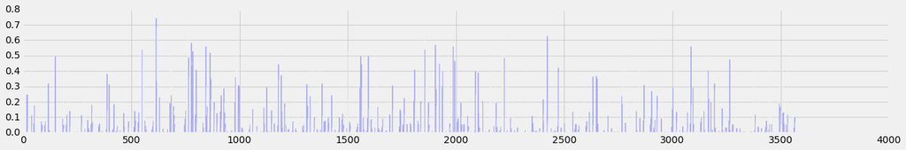

```python
plots.figure(figsize=(20,3))
plots.bar(np.arange(env_len),1-env_max_freq, width=.5)
plots.show()
```

So it seems that most of the positions are mostly conserved. There's a position around position 600 that seems to have a lot of variation.

**To think about**: How would you find out whether position 600 in this graph is assocated with any known important sites in hxb2? Specifically, how would you figure out the corresponding coordinate in hxb2?

**Q9**: Let's summarize this as a single number. What is the average maximum variant frequency across the env gene?

```python
# again, let's just do a crude calculation of the average max frequency across the env gene
np.mean(env_max_freq)
```

```
0.92402260194670127
```

**Q10**: Do a similar analysis for the pol gene. Which gene has more variation this time? Does this agree with the previous section?

## Quantifying variation (III)

This last part is optional but highly encouraged. Try to come up with your own metric for quantifying variation between two sequences and compare your metric between these two genes